# Import peaks into R

Franziska Greulich

2022-08-17

## 1. Import MACS peaks into R

We will work with peaks called by MACS. I provided an example peak set in the ./data/MACS/ sub directory which I will use to illustrate the different import options. However, later you gonna use you own data in the exercise.  
**1. import BED files**

```r
#read input data in BED format: Example of a _summit.bed MACS output.
peaks_bed <- read.table("./data/MACS/hMonocytes_4h1uMTA_aGR_rep1_SRR6497267overSRR6497265_SE_hg38_FDR005_summits.bed", header = FALSE, sep = '\t', stringsAsFactors = FALSE)

#show the first 10 lines
head(peaks_bed, 10)
```

```
##    V1        V2        V3
## 1   1  33339060  33339061
## 2   1 111489800 111489801
## 3   1 198776896 198776897
## 4  10  20003962  20003963
## 5  10  72249033  72249034
## 6  11 114154606 114154607
## 7  11 114164080 114164081
## 8  11 114179448 114179449
## 9  12   7557526   7557527
## 10 12  68787600  68787601
##                                                                             V4
## 1   hMonocytes_4h1uMTA_aGR_rep1_SRR6497267overSRR6497265_SE_hg38_FDR005_peak_1
## 2   hMonocytes_4h1uMTA_aGR_rep1_SRR6497267overSRR6497265_SE_hg38_FDR005_peak_2
## 3   hMonocytes_4h1uMTA_aGR_rep1_SRR6497267overSRR6497265_SE_hg38_FDR005_peak_3
```

[output cut: 18 more lines]

The function `read.table` reads an input file and transformed it into a data.frame, the basic data structure in R. Lines starting with # are ignored by default and the option `header=FALSE` indicates that the first line does not contain column names.  
You can assign column names to make the table more readable.

```r
#Assign column names to peaks_bed data frame.
colnames(peaks_bed) <- c("chr","start","end","name","score")

#Show the top rows
head(peaks_bed)
```

```
##   chr     start       end
## 1   1  33339060  33339061
## 2   1 111489800 111489801
## 3   1 198776896 198776897
## 4  10  20003962  20003963
## 5  10  72249033  72249034
## 6  11 114154606 114154607
##                                                                         name
## 1 hMonocytes_4h1uMTA_aGR_rep1_SRR6497267overSRR6497265_SE_hg38_FDR005_peak_1
## 2 hMonocytes_4h1uMTA_aGR_rep1_SRR6497267overSRR6497265_SE_hg38_FDR005_peak_2
## 3 hMonocytes_4h1uMTA_aGR_rep1_SRR6497267overSRR6497265_SE_hg38_FDR005_peak_3
## 4 hMonocytes_4h1uMTA_aGR_rep1_SRR6497267overSRR6497265_SE_hg38_FDR005_peak_4
## 5 hMonocytes_4h1uMTA_aGR_rep1_SRR6497267overSRR6497265_SE_hg38_FDR005_peak_5
## 6 hMonocytes_4h1uMTA_aGR_rep1_SRR6497267overSRR6497265_SE_hg38_FDR005_peak_6
##      score
## 1  2.29619
## 2  8.37238
## 3  4.81979
## 4  2.83584
## 5  2.29619
## 6 10.84952
```

**2. import narrowPeak files**  
Similar to BED files, narrowPeak files are standard tab-delimited and can be read using the `read.table` function of R. They do not contain a header, so we have to define the column names manually.

```r
#read input data in narrowPeak format: Example of a _peaks.narrowPeak MACS output.
peaks_narrow <- read.table("./data/MACS/hMonocytes_4h1uMTA_aGR_rep1_SRR6497267overSRR6497265_SE_hg38_FDR005_peaks.narrowPeak", header = FALSE, sep = '\t', stringsAsFactors = FALSE)

#show the first 10 lines
head(peaks_narrow, 10)
```

```
##    V1        V2        V3
## 1   1  33338963  33339095
## 2   1 111489759 111489936
## 3   1 198776741 198776902
## 4  10  20003900  20004006
## 5  10  72248903  72249062
## 6  11 114154531 114154770
## 7  11 114164012 114164102
## 8  11 114179284 114179491
## 9  12   7557332   7557613
## 10 12  68787556  68787648
##                                                                             V4
## 1   hMonocytes_4h1uMTA_aGR_rep1_SRR6497267overSRR6497265_SE_hg38_FDR005_peak_1
## 2   hMonocytes_4h1uMTA_aGR_rep1_SRR6497267overSRR6497265_SE_hg38_FDR005_peak_2
## 3   hMonocytes_4h1uMTA_aGR_rep1_SRR6497267overSRR6497265_SE_hg38_FDR005_peak_3
```

[output cut: 18 more lines]

```r
#Assign column names.
colnames(peaks_narrow) <- c("chr","start","end","name","score","strand","fold-change","pvalue_log10","qvalue_log10","summit")

#Show the top rows
head(peaks_narrow)
```

```
##   chr     start       end
## 1   1  33338963  33339095
## 2   1 111489759 111489936
## 3   1 198776741 198776902
## 4  10  20003900  20004006
## 5  10  72248903  72249062
## 6  11 114154531 114154770
##                                                                         name
## 1 hMonocytes_4h1uMTA_aGR_rep1_SRR6497267overSRR6497265_SE_hg38_FDR005_peak_1
## 2 hMonocytes_4h1uMTA_aGR_rep1_SRR6497267overSRR6497265_SE_hg38_FDR005_peak_2
## 3 hMonocytes_4h1uMTA_aGR_rep1_SRR6497267overSRR6497265_SE_hg38_FDR005_peak_3
## 4 hMonocytes_4h1uMTA_aGR_rep1_SRR6497267overSRR6497265_SE_hg38_FDR005_peak_4
## 5 hMonocytes_4h1uMTA_aGR_rep1_SRR6497267overSRR6497265_SE_hg38_FDR005_peak_5
## 6 hMonocytes_4h1uMTA_aGR_rep1_SRR6497267overSRR6497265_SE_hg38_FDR005_peak_6
##   score strand fold-change pvalue_log10 qvalue_log10 summit
## 1    22      .     5.19504      6.95301      2.29619     97
## 2    83      .     8.41439     13.70057      8.37238     41
## 3    48      .     6.12064      9.70412      4.81979    155
## 4    28      .     4.75220      7.53305      2.83584     62
## 5    22      .     5.19504      6.95301      2.29619    130
## 6   108      .     9.48454     16.57649     10.84952     75
```

**3. import MACS .xls files**  
In contrast to BED and NarrowPeak files, MACS _peaks.xls files contain meta data within the first rows as well as column headers. By default the `read.table` function ignores commented rows. In order to include them, set the `comment.char` argument to ““. MACS _peaks.xls files already contain a header row, therefor set the header argument to `header=TRUE`.

```r
#read input data in XLS format: Example of a _peaks.xls MACS output.
peaks_macs <- read.table("./data/MACS/hMonocytes_4h1uMTA_aGR_rep1_SRR6497267overSRR6497265_SE_hg38_FDR005_peaks.xls", header = TRUE, sep = '\t', stringsAsFactors=FALSE)

#show the top rows
head(peaks_macs)
```

```
##   chr     start       end length abs_summit pileup X.log10.pvalue.
## 1   1  33338964  33339095    132   33339061   9.39         6.95301
## 2   1 111489760 111489936    177  111489801  14.36        13.70057
## 3   1 198776742 198776902    161  198776897  14.91         9.70412
## 4  10  20003901  20004006    106   20003963  13.26         7.53305
## 5  10  72248904  72249062    159   72249034   9.39         6.95301
## 6  11 114154532 114154770    239  114154607  16.02        16.57649
##   fold_enrichment X.log10.qvalue.
## 1         5.19504         2.29619
## 2         8.41439         8.37238
## 3         6.12064         4.81979
## 4         4.75220         2.83584
## 5         5.19504         2.29619
## 6         9.48454        10.84952
##                                                                         name
## 1 hMonocytes_4h1uMTA_aGR_rep1_SRR6497267overSRR6497265_SE_hg38_FDR005_peak_1
## 2 hMonocytes_4h1uMTA_aGR_rep1_SRR6497267overSRR6497265_SE_hg38_FDR005_peak_2
## 3 hMonocytes_4h1uMTA_aGR_rep1_SRR6497267overSRR6497265_SE_hg38_FDR005_peak_3
## 4 hMonocytes_4h1uMTA_aGR_rep1_SRR6497267overSRR6497265_SE_hg38_FDR005_peak_4
## 5 hMonocytes_4h1uMTA_aGR_rep1_SRR6497267overSRR6497265_SE_hg38_FDR005_peak_5
## 6 hMonocytes_4h1uMTA_aGR_rep1_SRR6497267overSRR6497265_SE_hg38_FDR005_peak_6
```

```r
#read input data in XLS format without ignoring commented rows.
peaks_macs_test <- read.table("./data/MACS/hMonocytes_4h1uMTA_aGR_rep1_SRR6497267overSRR6497265_SE_hg38_FDR005_peaks.xls", header = TRUE, sep = '\t', stringsAsFactors = FALSE, comment.char = "")

#show the top rows
head(peaks_macs_test)
```

```
##                                                                                                                                                                                                                                                                             X..This.file.is.generated.by.…
## 1 # Command line: callpeak -t /media/sf_shared/hMonocytes_4h1uMTA_aGR_rep1_SRR6497267_hg38_sort_noDupl_aligned.bam -c /media/sf_shared/hMonocytes_DMSO_aGR_rep1_SRR6497265_hg38_sort_noDupl_aligned.bam -n hMonocytes_4h1uMTA_aGR_rep1_SRR6497267overSRR6497265_SE_hg38_FDR005 --outdir /media/sf_shared/…
## 2                                                                                                                                                                                                                                                                                                        …
## 3                                                                                                                                                                                                                                                       # name = hMonocytes_4h1uMTA_aGR_rep1_SRR6497267ov…
## 4                                                                                                                                                                                                                                                                                                        …
## 5                                                                                                                                                                                                                           # ChIP-seq file = [/media/sf_shared/hMonocytes_4h1uMTA_aGR_rep1_SRR6497267_hg…
## 6                                                                                                                                                                                                                               # control file = [/media/sf_shared/hMonocytes_DMSO_aGR_rep1_SRR6497265_hg…
```

```r
#We could overcome the issue of meta data lines by skipping the first lines using the skip argument (in case those are not commented).
peaks_macs_test2 <- read.table("./data/MACS/hMonocytes_4h1uMTA_aGR_rep1_SRR6497267overSRR6497265_SE_hg38_FDR005_peaks.xls", header = TRUE, sep = '\t', stringsAsFactors=FALSE, comment.char = "", skip=27)

#show the top rows
head(peaks_macs_test2)
```

```
##   chr     start       end length abs_summit pileup X.log10.pvalue.
## 1   1  33338964  33339095    132   33339061   9.39         6.95301
## 2   1 111489760 111489936    177  111489801  14.36        13.70057
## 3   1 198776742 198776902    161  198776897  14.91         9.70412
## 4  10  20003901  20004006    106   20003963  13.26         7.53305
## 5  10  72248904  72249062    159   72249034   9.39         6.95301
## 6  11 114154532 114154770    239  114154607  16.02        16.57649
##   fold_enrichment X.log10.qvalue.
## 1         5.19504         2.29619
## 2         8.41439         8.37238
## 3         6.12064         4.81979
## 4         4.75220         2.83584
## 5         5.19504         2.29619
## 6         9.48454        10.84952
##                                                                         name
## 1 hMonocytes_4h1uMTA_aGR_rep1_SRR6497267overSRR6497265_SE_hg38_FDR005_peak_1
## 2 hMonocytes_4h1uMTA_aGR_rep1_SRR6497267overSRR6497265_SE_hg38_FDR005_peak_2
## 3 hMonocytes_4h1uMTA_aGR_rep1_SRR6497267overSRR6497265_SE_hg38_FDR005_peak_3
## 4 hMonocytes_4h1uMTA_aGR_rep1_SRR6497267overSRR6497265_SE_hg38_FDR005_peak_4
## 5 hMonocytes_4h1uMTA_aGR_rep1_SRR6497267overSRR6497265_SE_hg38_FDR005_peak_5
## 6 hMonocytes_4h1uMTA_aGR_rep1_SRR6497267overSRR6497265_SE_hg38_FDR005_peak_6
```

## Rename chromosomes and remove unconventional chromosomes

Chromosomes mapped using the ENSEMBL genome build (as in this example data) will be annotated by numbers only, whereas chromosomes in the NCBI/UCSC genome builds a annotated as “chr” + number. Furthermore, genome builds may contain additional chromosomes like alternative sequences or mitochondria, which might be irrelevant when studying nuclear processes.

```r
#look at chromosome annotation (using the narrowPeak file)
print("List of chromosome names according to original annotation:")
```

```
## [1] "List of chromosome names according to original annotation:"
```

```r
unique(peaks_narrow$chr)
```

```
##  [1] "1"          "10"         "11"         "12"         "13"
##  [6] "14"         "15"         "16"         "17"         "2"
## [11] "20"         "3"          "4"          "5"          "6"
## [16] "7"          "8"          "9"          "KI270731.1" "Y"
```

```r
#Paste the "chr" string in front of the  chromosome number to allow for compliance with downstream analysis using NCBI chromosome annotations (Note: This is only required if ENSMBL genome builds from past 2016 were used.)
peaks_narrow$chr<-paste("chr",peaks_narrow$chr,sep="")

print("List of chromosome names after pasting \"chr\":")
```

```
## [1] "List of chromosome names after pasting \"chr\":"
```

```r
unique(peaks_narrow$chr)
```

```
##  [1] "chr1"          "chr10"         "chr11"         "chr12"
##  [5] "chr13"         "chr14"         "chr15"         "chr16"
##  [9] "chr17"         "chr2"          "chr20"         "chr3"
## [13] "chr4"          "chr5"          "chr6"          "chr7"
## [17] "chr8"          "chr9"          "chrKI270731.1" "chrY"
```

```r
#filter chromosomes
#define "compliant" chromosomes
chrHs <- c("chr1","chr2","chr3","chr4","chr5","chr6","chr7","chr8","chr9","chr10","chr11","chr12","chr13","chr14","chr15","chr16","chr17","chr18","chr19","chr20","chr21","chr22","chrX","chrY")
#filter
peaks_narrow <- peaks_narrow[peaks_narrow$chr%in%chrHs,]

print("Remaining chromosomes after filtering:")
```

```
## [1] "Remaining chromosomes after filtering:"
```

```r
unique(peaks_narrow$chr)
```

```
##  [1] "chr1"  "chr10" "chr11" "chr12" "chr13" "chr14" "chr15" "chr16" "chr17"
## [10] "chr2"  "chr20" "chr3"  "chr4"  "chr5"  "chr6"  "chr7"  "chr8"  "chr9"
## [19] "chrY"
```

## Convert peaks into GRanges

A `GRange` object (from the `GenomicRanges` package) is an useful data type to store genomic locations and annotations. In order to make things easier, we define a function `bed2GRanges` that converts or imported tab-delimited data into a `GRange` object using the `GRanges` function from the `GenomicRanges` package. The minimal composition of a `GRange` object consists of `seqnames` holding the chromosome name and an `IRanges` object holding start and end coordinates as well as the strand information of the DNA sequence. Additional data can be provided as metadata columns.

```r
#load the GenomicRanges package
library("GenomicRanges")
```

```r
#define a function to convert BED formatted data into GRanges (the strand can be set to * for unstranded data such as ChIP)
#Note: If the peaks do not have specified names, you can generate unique names pasting chr, start and end
bed2GRanges <-function(peaks)
{
  myrange <- GRanges(seqnames = peaks[,1],range = IRanges(start = peaks[,2], end = peaks[,3], names = peaks[,4]), strand = "*")
  return(myrange)
}

#convert the filtered narrow peak file into a GRange object.
peaks_narrow_g <- bed2GRanges(peaks_narrow)

#Have a look at the GRange structure.
head(peaks_narrow_g)
```

```
## GRanges object with 6 ranges and 0 metadata columns:
##                                                                              seqnames
##                                                                                 <Rle>
##   hMonocytes_4h1uMTA_aGR_rep1_SRR6497267overSRR6497265_SE_hg38_FDR005_peak_1     chr1
##   hMonocytes_4h1uMTA_aGR_rep1_SRR6497267overSRR6497265_SE_hg38_FDR005_peak_2     chr1
##   hMonocytes_4h1uMTA_aGR_rep1_SRR6497267overSRR6497265_SE_hg38_FDR005_peak_3     chr1
##   hMonocytes_4h1uMTA_aGR_rep1_SRR6497267overSRR6497265_SE_hg38_FDR005_peak_4    chr10
##   hMonocytes_4h1uMTA_aGR_rep1_SRR6497267overSRR6497265_SE_hg38_FDR005_peak_5    chr10
##   hMonocytes_4h1uMTA_aGR_rep1_SRR6497267overSRR6497265_SE_hg38_FDR005_peak_6    chr11
##                                                                                           ranges
##                                                                                        <IRanges>
##   hMonocytes_4h1uMTA_aGR_rep1_SRR6497267overSRR6497265_SE_hg38_FDR005_peak_1   33338963-33339095
##   hMonocytes_4h1uMTA_aGR_rep1_SRR6497267overSRR6497265_SE_hg38_FDR005_peak_2 111489759-111489936
##   hMonocytes_4h1uMTA_aGR_rep1_SRR6497267overSRR6497265_SE_hg38_FDR005_peak_3 198776741-198776902
##   hMonocytes_4h1uMTA_aGR_rep1_SRR6497267overSRR6497265_SE_hg38_FDR005_peak_4   20003900-20004006
##   hMonocytes_4h1uMTA_aGR_rep1_SRR6497267overSRR6497265_SE_hg38_FDR005_peak_5   72248903-72249062
##   hMonocytes_4h1uMTA_aGR_rep1_SRR6497267overSRR6497265_SE_hg38_FDR005_peak_6 114154531-114154770
##                                                                              strand
##                                                                               <Rle>
##   hMonocytes_4h1uMTA_aGR_rep1_SRR6497267overSRR6497265_SE_hg38_FDR005_peak_1      *
##   hMonocytes_4h1uMTA_aGR_rep1_SRR6497267overSRR6497265_SE_hg38_FDR005_peak_2      *
##   hMonocytes_4h1uMTA_aGR_rep1_SRR6497267overSRR6497265_SE_hg38_FDR005_peak_3      *
##   hMonocytes_4h1uMTA_aGR_rep1_SRR6497267overSRR6497265_SE_hg38_FDR005_peak_4      *
##   hMonocytes_4h1uMTA_aGR_rep1_SRR6497267overSRR6497265_SE_hg38_FDR005_peak_5      *
##   hMonocytes_4h1uMTA_aGR_rep1_SRR6497267overSRR6497265_SE_hg38_FDR005_peak_6      *
##   -------
##   seqinfo: 19 sequences from an unspecified genome; no seqlengths
```

We can add more meta data.

```r
# add metadata.
peaks_narrow_g <- GRanges(seqnames = peaks_narrow$chr,range = IRanges(start = peaks_narrow$start, end = peaks_narrow$end, names = peaks_narrow$name), strand="*", FC = peaks_narrow$`fold-change`, qvalue = peaks_narrow$qvalue_log10)

#add metadata on predefined metadata columns (in GRanges function) downstream (see ?GRanges for more info)
score(peaks_narrow_g) <- peaks_narrow$score

#or overwrite existing data
names(peaks_narrow_g) <- paste(peaks_narrow$chr,peaks_narrow$start,peaks_narrow$end,sep="_")

#Show the GRange object including metadata.
head(peaks_narrow_g)
```

```
## GRanges object with 6 ranges and 3 metadata columns:
##                             seqnames              ranges strand |        FC
##                                <Rle>           <IRanges>  <Rle> | <numeric>
##      chr1_33338963_33339095     chr1   33338963-33339095      * |   5.19504
##    chr1_111489759_111489936     chr1 111489759-111489936      * |   8.41439
##    chr1_198776741_198776902     chr1 198776741-198776902      * |   6.12064
##     chr10_20003900_20004006    chr10   20003900-20004006      * |   4.75220
##     chr10_72248903_72249062    chr10   72248903-72249062      * |   5.19504
##   chr11_114154531_114154770    chr11 114154531-114154770      * |   9.48454
##                                qvalue     score
##                             <numeric> <integer>
##      chr1_33338963_33339095   2.29619        22
##    chr1_111489759_111489936   8.37238        83
##    chr1_198776741_198776902   4.81979        48
##     chr10_20003900_20004006   2.83584        28
##     chr10_72248903_72249062   2.29619        22
##   chr11_114154531_114154770  10.84952       108
##   -------
##   seqinfo: 19 sequences from an unspecified genome; no seqlengths
```

Access information stored in the `GRanges` object using accessor functions:

```r
#Metadata
mcols(peaks_narrow_g)
```

```
## DataFrame with 201 rows and 3 columns
##                                 FC    qvalue     score
##                          <numeric> <numeric> <integer>
## chr1_33338963_33339095     5.19504   2.29619        22
## chr1_111489759_111489936   8.41439   8.37238        83
## chr1_198776741_198776902   6.12064   4.81979        48
## chr10_20003900_20004006    4.75220   2.83584        28
## chr10_72248903_72249062    5.19504   2.29619        22
## ...                            ...       ...       ...
## chrY_56768992_56769520     9.54221  13.82780       138
## chrY_56769662_56770268    13.27850  22.85697       228
## chrY_56770402_56770628     5.77358   7.48865        74
## chrY_56770802_56770878     4.30935   4.90638        49
## chrY_56771218_56771453     6.37261   8.51396        85
```

```r
#Fold-change
mcols(peaks_narrow_g)$FC
```

```
##   [1]  5.19504  8.41439  6.12064  4.75220  5.19504  9.48454  5.47122  9.06155
##   [9] 10.31862  6.85212 10.16627  6.86408  7.29682  4.01572 12.09952  5.76723
##  [17]  9.48454  6.96163  7.04377  6.64532  8.17830  5.59329  5.08313  5.74740
##  [25]  5.19504  7.60160  9.79238  4.01572  6.35399  6.55346  4.72934  6.06266
##  [33]  8.50919  5.30456  6.87747  5.47122 12.09952  9.17671 11.94723  7.43052
##  [41]  7.12830  4.93632  6.59339  4.25460  6.59339  5.91167  9.78926  6.46403
##  [49] 10.58200  9.40230 14.68088  9.00440  6.74976 10.36955  7.85890 12.31156
##  [57]  7.50618  7.62041  7.20085  7.42106 10.40708  6.22515 10.26272  6.27594
##  [65]  7.93301  3.73509  8.12054  4.80696  6.16547  9.76002 13.20560  8.25436
##  [73] 12.21554  4.06651  9.61149  9.76002  6.31218 11.76980  6.77751 12.48521
##  [81]  5.08313  9.01559  4.30935  7.51399  8.66904  7.51527  6.82830  6.04976
##  [89]  5.82362  4.16718  3.62462  6.71108  5.49740  6.96163  6.84584  6.54616
##  [97]  4.66887  7.67884 10.06482 11.71143  6.77751 12.91422  8.91778  9.35518
## [105]  8.84331  8.06635  6.22515  4.28745 10.74246  3.37810  3.66494  8.45318
## [113]  5.91167  7.68971  7.15971  7.88223  6.46403  8.86155  7.96735 11.72618
## [121]  8.61871  6.46403  8.43459  3.94111  5.22122  6.04976  7.51399  9.01849
## [129]  6.85200  7.42106  6.04103  5.83405  7.88223  4.94504  6.43254  6.73243
## [137]  6.18785  7.45033  6.75798  9.70575  9.94466  7.62041 11.56462  7.21444
## [145] 12.53997  6.15222  6.96163  8.45754 13.22169  7.79976  4.21729  5.13789
## [153]  6.60212  6.04976  7.13198  8.40115  6.22515  5.94590  8.29421 13.20560
## [161]  7.18287 11.24702  7.57688  6.00293  6.05197  8.41611  8.43459 10.03362
## [169]  6.87830  9.17107  8.43190  7.83932  4.66887  5.28170  9.34237  5.35931
## [177]  7.15448  5.91167  7.73818 10.47386  3.53591 13.68054  8.83892  6.62747
## [185]  7.84493  8.18466  9.18532  8.46944  6.01621  6.08699  9.02664 13.30812
## [193] 10.48474  6.06759 14.19704 13.22169  9.54221 13.27850  5.77358  4.30935
## [201]  6.37261
```

```r
#genomic location only
granges(peaks_narrow_g)
```

```
## GRanges object with 201 ranges and 0 metadata columns:
##                            seqnames              ranges strand
##                               <Rle>           <IRanges>  <Rle>
##     chr1_33338963_33339095     chr1   33338963-33339095      *
##   chr1_111489759_111489936     chr1 111489759-111489936      *
##   chr1_198776741_198776902     chr1 198776741-198776902      *
##    chr10_20003900_20004006    chr10   20003900-20004006      *
##    chr10_72248903_72249062    chr10   72248903-72249062      *
##                        ...      ...                 ...    ...
##     chrY_56768992_56769520     chrY   56768992-56769520      *
##     chrY_56769662_56770268     chrY   56769662-56770268      *
##     chrY_56770402_56770628     chrY   56770402-56770628      *
##     chrY_56770802_56770878     chrY   56770802-56770878      *
##     chrY_56771218_56771453     chrY   56771218-56771453      *
##   -------
##   seqinfo: 19 sequences from an unspecified genome; no seqlengths
```

Let’S extract some useful information from the GRange object for exploratory analysis.  
a.) How many peaks are contained?

```r
length(peaks_narrow_g)
```

```
## [1] 201
```

b.) Distribution of peak sizes:

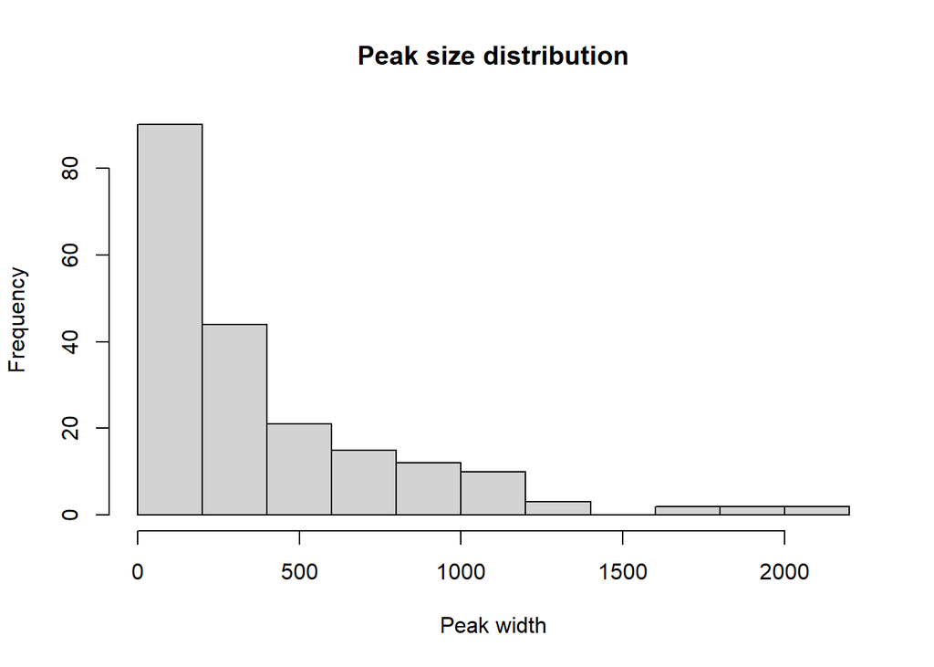

```r
hist(width(peaks_narrow_g), main = "Peak size distribution", xlab = "Peak width")
```

c.) Distribution of p-values:

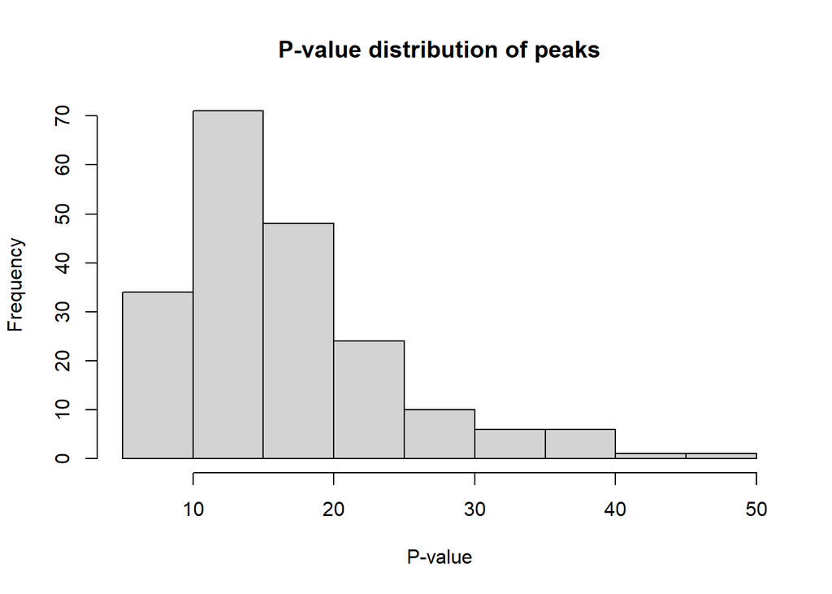

```r
peaks_narrow_g <- GRanges(seqnames = peaks_narrow$chr,range = IRanges(start = peaks_narrow$start, end = peaks_narrow$end, names = peaks_narrow$name), strand = "*", FC = peaks_narrow$`fold-change`, qvalue = peaks_narrow$qvalue_log10, pvalue =  peaks_narrow$pvalue_log10)
hist(mcols(peaks_narrow_g)$pvalue, main = "P-value distribution of peaks", xlab = "P-value")
```

```r
#import blacklisted regions from bed file (downloaded from https://github.com/Boyle-Lab/Blacklist/tree/master/lists) and convert to GRange object
blacklist <- read.table("./data/hg38-blacklist.v2.bed", header = FALSE, stringsAsFactors = FALSE, fill = TRUE)
blacklist_g <- bed2GRanges(blacklist)

#calculate the percent overlap of all peaks with blacklisted regions
print(paste(round(100*length(subsetByOverlaps(peaks_narrow_g, blacklist_g, minoverlap = 1, ignore.strand = TRUE))/length(peaks_narrow_g), 2), "% overlap ENCODE-blacklisted regions.", sep=" "))
```

```
## [1] "84.08 % overlap ENCODE-blacklisted regions."
```

```r
#remove blacklisted regions
peaks_narrow_g <- subsetByOverlaps(peaks_narrow_g,blacklist_g,invert = TRUE, minoverlap = 1, ignore.strand = TRUE)

#print the number of peaks per sample after removal of ENCODE blacklisted regions
print(paste(length(peaks_narrow_g), "peaks remain after removal of ENCODE's blacklisted regions.", sep =" "))
```

```
## [1] "32 peaks remain after removal of ENCODE's blacklisted regions."
```

This was the first part. More complex operations follow using multiple peak files in `PeakOverlapsAndAnnotations.Rmd`.